# Final Paper

STOR 320.01 Group 1

June 20, 2025

# INTRODUCTION

Scooby-Doo has become a cultural icon in the United States. Many generations of children have grown up watching Scooby-Doo and aspired to solve crimes like the characters on the show. For our group project, we decided to look at a dataset containing information on every episode, movie, or special of Scooby-Doo from 1969, the first year that the characters featured in a tv series, up until 2021.

Our first question asks: What factors influence the ratings of the show the most, and how does the importance of various factors change over time? This question is aimed at producers and screenwriters for the show. We wanted to explore what factors impact the ratings the most so that they could use that information to create episodes that contain the factors that will draw audiences in the most. By understanding the factors, whether it’s the villain’s identity, the setting, or who catches the villain, more engaging content can be made. In turn the viewers will also benefit as episodes created taking into account what factors boost ratings will likely contain the same factors that viewers want to see in a Scooby-Doo episode.

For our second question, we decided to think outside the box and bring in outside crime data. We wanted to see if there was any connection between crimes in real life and crimes in Scooby-Doo, specifically: Are kids influenced by what they see on Scooby-Doo and as a result when they see villains stealing/getting arrested on the show can that influence if they will commit crimes themselves? We wanted to investigate juvenile crime rates as Scooby-Doo’s primary audience is children and we therefore assumed that children would be the most influenced by the show. This question would be important to both parents and law enforcement. If Scooby-Doo does influence the crimes that children commit, that might influence whether or not parents choose to let their children watch the show and it might help law influence predict what crimes children might be more likely to commit.

As Scooby-Doo continues to occupy an important place in popular culture, investigating these questions will allow producers and viewers alike to know more about the show, what makes it popular and what influence that popularity might have.

# DATA

Our dataset [Scooby Doo Complete](https://www.kaggle.com/datasets/williamschooleman/scoobydoo-complete/data) was found on Kaggle and was created by William C. Schooleman, whose Kaggle username is plummye. He watched every episode of Scooby-Doo and kept track of 77 different variables. These variables include information on the name, series, network, villains, events, phrases, and characters, among other things, in each episode. The dataset tracks these variables for 615 observations, each one being a different episode, movie, or special. This dataset was last updated in 2021.

While we did use most of the variables in our full model, it would be overwhelming to describe what all 77 variables represented. We will therefore provide descriptions of only the variables that proved most important to our models. The `imdb` variable listed the imdb rating as of the last time this dataset was updated and the `engagement` variable represents the popularity of the episode, and is the number of people who rated the episode on imdb. The `network` variable is the tv network on which the episode originally aired. The `date.aired` variable was the combination of the month, day and year variables and was the date on which the episode originally aired. The variable `motive` described the motivation behind the crimes of the villian(s) in that episode. The `arrested` variable is a boolean variable that is true when the villain(s) in the episode were arrested and false when they were not. The variable ‘culprit.amount’ was an integer that represented how many culprits were in the episode. The variable `caught.”character”` variables described which character caught the villain. There were five of these variables, one for each of the mystery gang characters, and were boolean variables that were true when that character caught the villain. The `captured.”character”` variables are formatted the same as the `caught.”character”` variables and describe whether that character was captured by the villain in that episode. The `scrappy.doo`, `batman`, and `Scooby.dum` variables were boolean variables that were true when that character was in an episode. The `monster.real` variable was a boolean variable that was true when the monster, or the most prevalent monster in episodes where more than one existed, was real, or in other words not a person in a mask or mechanically controlled.

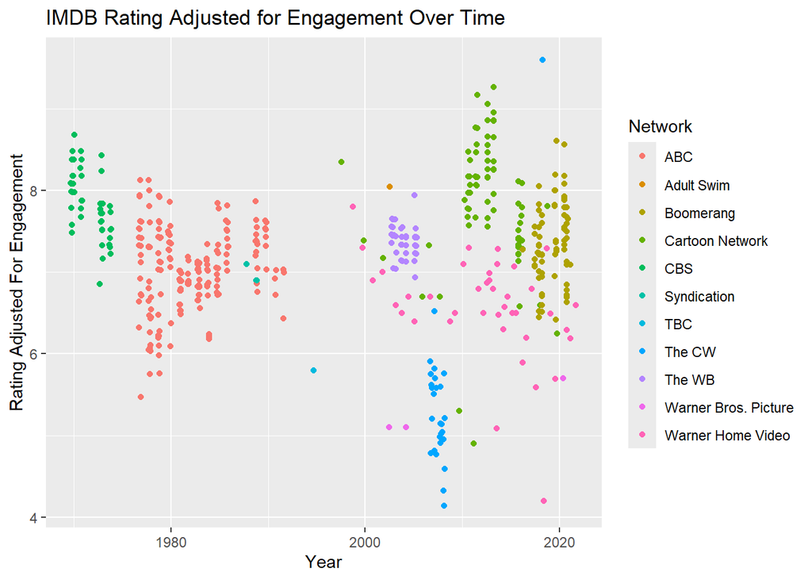

To investigate our second question involving crime data, we also used data on juvenile crimes in the United States. The data [Juvenile Crimes](https://ojjdp.ojp.gov/statistical-briefing-book/crime#4-0) came from the Office of Juvenile Justice and Delinquency Prevention which is under the Department of Justice. During the cleaning we converted the spreadsheet into a cvs file and picked the first table in the set that looked at the total juvenile crime rates by year. Then we narrowed the set down to four variables from this dataset in our analysis. The `Year` variable describes the year in which those crimes took place. The `Overall Juvenile Crime Rate` variable describes the overall juvenile crime rate per 100,000 people for that year. The `Robbery Rates` and `Burglary Rates` variables (The difference between the 2 is that Robbery involves the use of violence) describe the crime rates for those specific crimes for that year. This dataset spanned the years 1980 to 2020 and had 41 observations and we added 3 lag variables that lagged `Overall Juvenile Crime Rate`, `Robbery Rates`, and `Burglary Rates` to be later used for predictive modeling.

| Year | Overall Juvenile Crime Rate | Robbery Rates | Burglary Rates | Lagged Robbery Rates | Lagged Burglary Rates | Lagged Overall Juvenile Crime Rate |
| --- | --- | --- | --- | --- | --- | --- |
| 1980 | 6396.6 | 145.1 | 728.4 |  |  |  |
| 1981 | 6370.3 | 146.5 | 707.5 | 145.1 | 728.4 | 6396.6 |
| 1982 | 6607.7 | 137.5 | 684.6 | 146.5 | 707.5 | 6370.3 |
| 1983 | 6073.9 | 129.7 | 609.8 | 137.5 | 684.6 | 6607.7 |
| 1984 | 6110.2 | 121.9 | 553 | 129.7 | 609.8 | 6073.9 |
| 1985 | 6466.1 | 121.9 | 585.2 | 121.9 | 553 | 6110.2 |
| 1986 | 6728.5 | 119.4 | 568.7 | 121.9 | 585.2 | 6466.1 |

# RESULTS

## Question 1

In question one we looked at how various factors from the show impact ratings. To do this we first started with some data cleaning. We converted all numeric variables to double, converted boolean variables to logical, and converted categorical variables to factor variables to make them easier to work with for our models. We then created our own rating variable, called imdb_engagement, which took the imdb variable and weighed it based on popularity using the engagement variable. Since imdb scores are not already weighed by popularity and some of our observations, specifically some of the movies and specials had significantly higher engagement, we decided that we wanted to weight the imdb scores based on popularity to account for any scoring inequalities that might occur when an observation had very few or significantly more imdb raters than other observations. We used this formula to accomplish this: $1/engagement*.5 + ((engagement - 1)/engagement)*imdb$

This formula is intended to place more weight on engagement for episodes that have lower engagement. We ended up needing to remove some variables from the original dataset in order to perform the cross validation needed for our models. These variables were ones that had so many different possibilities that not all of the possibilities would be represented in a single cross validation train dataset. This group included variables like `series.name`, `title`, `monster.name`, `monster.type`, `monster.gender`, and the voice actor variables. Many of these problems stem from some episodes having more than one monster and therefore having multiple types or genders listed per episode. While we attempted to include these variables in our analysis, we were unable to find a workaround for this issue and therefore these variables are not included in any of our models. The last cleaning step we did was to remove rows with NA’s. Most of these rows fell into two categories. The first group was episodes that aired for the first time in October 2021. Since these episodes aired right before the last time this dataset was updated, these episodes did not have enough votes on imdb for reasonable conclusions to be drawn from their ratings and therefore their imdb and engagement columns were left blank by the creator of the dataset. Since we don’t have the imdb score for these episodes and that is what we are trying to predict, it makes sense to remove these rows. The other group that was removed was episodes that contained zero monsters. Many of these episodes were from the tv show Laff-a-Lympics. This show featured many characters, including the Scooby-Doo mystery gang, but were not formatted like other Scooby-Doo episodes. It therefore makes sense to remove them from our analysis because these episodes do not have many of the factors that traditional Scooby-Doo episodes have. We then created our cross fold data and began the analysis.

After cleaning the data, we started fitting models to predict our imdb_engagement variable. We first started by fitting two basic linear models, a full model and a blank model. The full model included all variables from the dataset other than those we had to remove during cleaning. Our empty model served as our baseline as was a horizontal line equal to the mean imdb_engagement score. We then used our full model to create a top variable model, which included the 6 variables with the most impact on the full model, which can be seen in the table below. When doing our initial exploration of the data, we noticed that many of the variables varied by year, with there being two distinct time frames. We therefore decided to create a model that took our top variable model and added the interactions between those variables and our date.aired variable to see if we could improve our top model. Out of these four models, the best model was the model that included the date interactions, though this model was only marginally better than our top variable model.

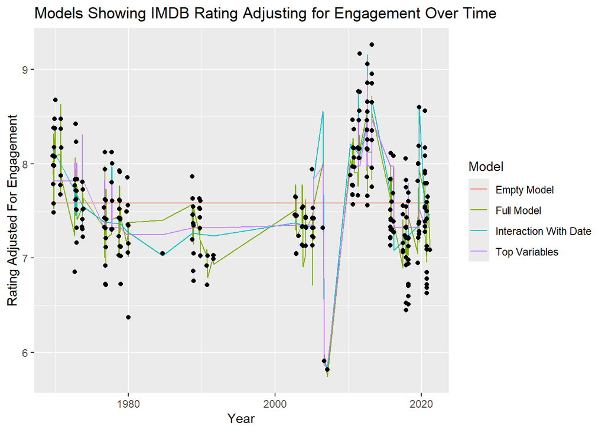

Since our data seemed to be split into two different time periods, we also decided to fit models specific to those time periods. We split the data at the largest gap in when episodes aired, which was around 1995. This also is roughly the halfway point in our data. We then fit a full model to each time period. These models ended up not improving upon our previous models, but from these time period models we were able to determine which factors influenced the rating the most for each time period.

Between the two time periods there are some comparisons that we can make. The `batman` variable had the most significant difference between the two time periods. Before 1995 the inclusion of Batman had a negative impact on ratings, while in later series Batman had a positive impact on ratings. The opinion of `monster.real` changed a lot, with viewers of earlier years preferring the monster to not be real but viewers of more recent series preferring the monster to be real. Several character actions can also explain how much viewers tend to like specific characters. Across both eras, Daphne’s actions have a positive impact on the ratings while Velma’s actions have a consistent negative impact on the ratings. Looking overall at both the full model and the time period models, variables relating to the network, inclusion of special characters (like Batman or Scrappy Doo), whether the monster was real, and mystery gang member actions seem to have the most impact on our models.

| Top Variables for Full Model | Coefficient Value (Full Model) | Top Variables Pre-1995 | Coefficient Value (Pre-1995 Model) | Top Variables Post-1995 | Coefficient Value (Post-1995 Model) |
| --- | --- | --- | --- | --- | --- |
| (Intercept) | 8.56331758148543 | (Intercept) | 8.32481672807817 | (Intercept) | 9.55362746980077 |
| networkCartoon Network | 3.60292925818571 | caught.daphneTRUE | 0.690381455925383 | networkThe CW | -3.90211565026293 |
| networkBoomerang | 3.29420577636898 | captured.scoobyTRUE | -0.676424323888735 | batmanTRUE | 1.4144066471559 |
| networkThe WB | 2.4191989725819 | monster.realTRUE | -0.639014463754104 | monster.realTRUE | 0.692773762188498 |
| scooby.dumTRUE | 0.831140543076434 | caught.velmaTRUE | -0.511694990427097 | networkThe WB | -0.645837013559864 |
| networkThe CW | -0.749933324018773 | batmanTRUE | -0.49990517703755 | caught.notTRUE | 0.478661808425985 |
| caught.notTRUE | 0.704777056003086 | snack.shaggyTRUE | 0.451889912309716 | captured.velmaTRUE | -0.397525096718302 |
| scrappy.dooTRUE | -0.479973559759515 | scrappy.dooTRUE | -0.450520381161819 | groovy | 0.337291339948822 |
| networkCBS | -0.439805455116329 | door.gagTRUE | 0.348345681486537 | captured.daphneTRUE | 0.263379650142656 |
| monster.realTRUE | 0.400778382551077 | snack.velmaTRUE | -0.338240109554917 | unmask.scoobyTRUE | 0.262282399832238 |
| snack.fredTRUE | 0.373427809780522 | arrestedTRUE | 0.335654331095725 | networkCartoon Network | 0.256594147375614 |

## Question 2

For our second question we wanted to investigate any possible real world impacts Scooby-Doo has had. We decided to focus on juvenile crime rates as Scooby-Doo is a kids show that focuses on solving mysteries to thwart criminals. Since the villains on the show primarily commit crimes related to stealing, we wanted to focus on those crimes. We cleaned some of our datasets and created new variables before we could begin our analysis. For the juvenile crime dataset, we selected to only look at overall, robbery, and burglary rates as those were the crimes that were most committed on Scooby-Doo. We then created three new lag variables that lagged each of those crime rate variables. We decided to lag the juvenile crime rate variables as we believe that kids would not watch a crime on Scooby-Doo and then commit it the next day. By lagging the crime rates, we assume that Scooby-Doo influenced crimes the children who watched it committed in the future, and are therefore able to use this model to predict the future juvenile crime rates.

For the Scooby-Doo dataset, we started by converting all numeric variables to double, boolean variables to logical, and categorical variables as we did for the last question. We then changed the levels of the motive factor variable to lump together the motives Natural Resource, Treasure, Theft, and Inheritance into a stealing group, as all of these crimes are related to stealing. All of the other motives were revealed into an “other” group (like NULL and “competition”) as these were not crimes we wanted to look at. We then created a percent_stealing variable that represents the percentage of episodes per year where stealing something was the main motive of the villain. We also thought children might be less likely to commit crimes if they see that those crimes have consequences, so we also created a percent_arrested variable that took the arrested variable and found the percentage of episodes that had the culprits arrested by year. We then created two new variables based on these percentage variables called arrest_lag and stealing_lag, which lagged those percentages by a year. We did this to account for the crimes that would have happened after someone could have watched and been influenced by the show. The last thing we did to the Scooby-Doo dataset was filter out episodes that occurred from 1980 onwards, since those are the years we have crime data for.

We then started by fitting models to the juvenile crime data, first only using data from that dataset. We wanted to first create models that predicted the juvenile crime data and then add in Scooby-Doo data to see if the addition of Scooby-Doo factors can improve those models. We decided we wanted to create models to predict burglary rates, as robbery includes violence and Scooby-Doo does not contain much violence as it is a kids show. We created nine models, with three different model types and three different models per type:

### Linear Models

**Linear Model 1**
$$\text{Burglary} = \beta_0 + \beta_1 \cdot \text{Robbery_lag} + \beta_2
\cdot \text{Burglary_lag} + \beta_3 \cdot \text{crimes_lag} + \epsilon$$

**Linear Model 2**
$$\text{Burglary} = \beta_0 + \beta_1 \cdot \text{Robbery_lag} + \beta_2
\cdot \text{Burglary_lag} + \epsilon$$

**Linear Model 3**
$$\text{Burglary} = \beta_0 + \beta_1 \cdot \text{Burglary_lag} + \epsilon$$

### Log-Transformed Models

**Log Model 1**
$$\log(\text{Burglary}) = \beta_0 + \beta_1 \cdot \text{Robbery_lag} +
\beta_2 \cdot \text{Burglary_lag} + \beta_3 \cdot \text{crimes_lag} +
\epsilon$$

**Log Model 2**
$$\log(\text{Burglary}) = \beta_0 + \beta_1 \cdot \text{Robbery_lag} +
\beta_2 \cdot \text{Burglary_lag} + \epsilon$$

**Log Model 3**
$$\log(\text{Burglary}) = \beta_0 + \beta_1 \cdot \text{Burglary_lag} +
\epsilon$$

### Polynomial Models

**Polynomial Model 1**
$$\text{Burglary} = \beta_0 + \beta_1 \cdot \text{Robbery_lag} + \beta_2
\cdot \text{Burglary_lag} + \beta_3 \cdot \text{crimes_lag} + \beta_4
\cdot \text{crimes_lag}^2 + \beta_5 \cdot \text{crimes_lag}^3 + \epsilon$$

**Polynomial Model 2**
$$\text{Burglary} = \beta_0 + \beta_1 \cdot \text{Robbery_lag} + \beta_2
\cdot \text{Robbery_lag}^2 + \beta_3 \cdot \text{Burglary_lag} + \beta_4
\cdot \text{crimes_lag} + \beta_5 \cdot \text{crimes_lag}^2 + \beta_6
\cdot \text{crimes_lag}^3 + \epsilon$$

**Polynomial Model 3**
$$\text{Burglary} = \beta_0 + \beta_1 \cdot \text{Robbery_lag} + \beta_2
\cdot \text{Robbery_lag}^2 + \beta_3 \cdot \text{Burglary_lag} + \beta_4
\cdot \text{Burglary_lag}^2 + \beta_5 \cdot \text{crimes_lag} + \beta_6
\cdot \text{crimes_lag}^2 + \beta_7 \cdot \text{crimes_lag}^3 + \epsilon$$
Using cross-validation, we were able to find the two best models. We found that none of the log models were very good. We also found that models of the same type were relatively similar. We ended up selecting Linear Model 2 with an average RMSE of 19.46188 and Polynomial Model 1 with an average RMSE of 19.95817. These were our two best models based on average root mean squared error as RMSE penalizes larger errors more than smaller ones.

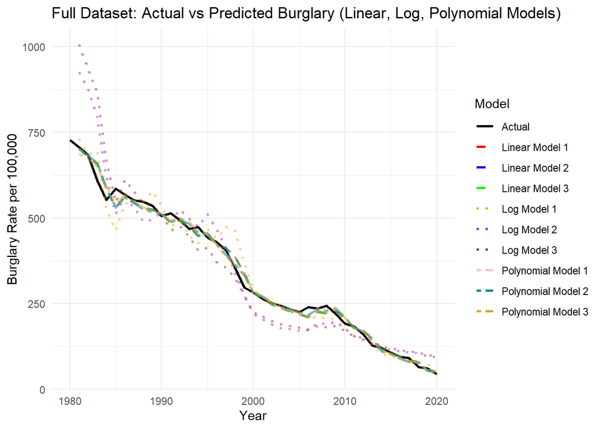

We then created three new models each based on the two best models, using factors from Scooby-Doo to see if adding Scooby-Doo improved our models. We ended up with the following eight models:

### Old Models

**Linear Model Original**
$$\text{Burglary} = \beta_0 + \beta_1 \cdot \text{Robbery_lag} + \beta_2
\cdot \text{Burglary_lag} + \epsilon$$

**Polynomial Model Original**
$$\text{Burglary} = \beta_0 + \beta_1 \cdot \text{Robbery_lag} + \beta_2
\cdot \text{Burglary_lag} + \beta_3 \cdot \text{crimes_lag} + \beta_4
\cdot \text{crimes_lag}^2 + \beta_5 \cdot \text{crimes_lag}^3 + \epsilon$$

### New Models with Scooby-Doo Factors

**New Linear Model 1**
$$\text{Burglary} = \beta_0 + \beta_1 \cdot \text{Robbery_lag} + \beta_2
\cdot \text{Burglary_lag} + \beta_3 \cdot \text{arrest_lag} + \beta_4
\cdot \text{stealing_lag} + \epsilon$$

**New Linear Model 2**
$$\text{Burglary} = \beta_0 + \beta_1 \cdot \text{Robbery_lag} + \beta_2
\cdot \text{Burglary_lag} + \beta_3 \cdot \text{stealing_lag} + \epsilon$$

**New Linear Model 3**
$$\text{Burglary} = \beta_0 + \beta_1 \cdot \text{Robbery_lag} + \beta_2
\cdot \text{Burglary_lag} + \beta_3 \cdot \text{arrest_lag} + \epsilon$$

**New Polynomial Model 1**
$$\begin{aligned}
\text{Burglary} &= \beta_0 + \beta_1 \cdot \text{Robbery_lag} +
\beta_2 \cdot \text{Burglary_lag} + \beta_3 \cdot \text{crimes_lag} +
\beta_4 \cdot \text{crimes_lag}^2 \\
&+ \beta_5 \cdot \text{crimes_lag}^3 + \beta_6 \cdot
\text{arrest_lag} + \beta_7 \cdot \text{arrest_lag}^2 + \beta_8 \cdot
\text{stealing_lag} + \beta_9 \cdot \text{stealing_lag}^2 + \epsilon
\end{aligned}$$

**New Polynomial Model 2**
$$\begin{aligned}
\text{Burglary} &= \beta_0 + \beta_1 \cdot \text{Robbery_lag} +
\beta_2 \cdot \text{Burglary_lag} + \beta_3 \cdot \text{crimes_lag} +
\beta_4 \cdot \text{crimes_lag}^2 + \beta_5 \cdot \text{crimes_lag}^3 \\
&+ \beta_6 \cdot \text{arrest_lag} + \beta_7 \cdot
\text{arrest_lag}^2 + \epsilon
\end{aligned}$$

**New Polynomial Model 3**
$$\begin{aligned}
\text{Burglary} &= \beta_0 + \beta_1 \cdot \text{Robbery_lag} +
\beta_2 \cdot \text{Burglary_lag} + \beta_3 \cdot \text{crimes_lag} +
\beta_4 \cdot \text{crimes_lag}^2 + \beta_5 \cdot \text{crimes_lag}^3 \\
&+ \beta_6 \cdot \text{stealing_lag} + \beta_7 \cdot
\text{stealing_lag}^2 + \epsilon
\end{aligned}$$

We then performed cross-validation and looked at root mean squared error to determine which of the models performed the best again. We determined that New Polynomial Model 1 was our best-fitting model as it had the lowest RMSE. This model does incorporate Scooby-Doo factors, so it does appear that Scooby-Doo factors might influence the juvenile crime rates. However, the difference between the 8 models was not very large, so while the Scooby-Doo factors do seem to improve the model, we cannot definitively say that those factors improve the model enough that law enforcement should start including Scooby-Doo data in their models.

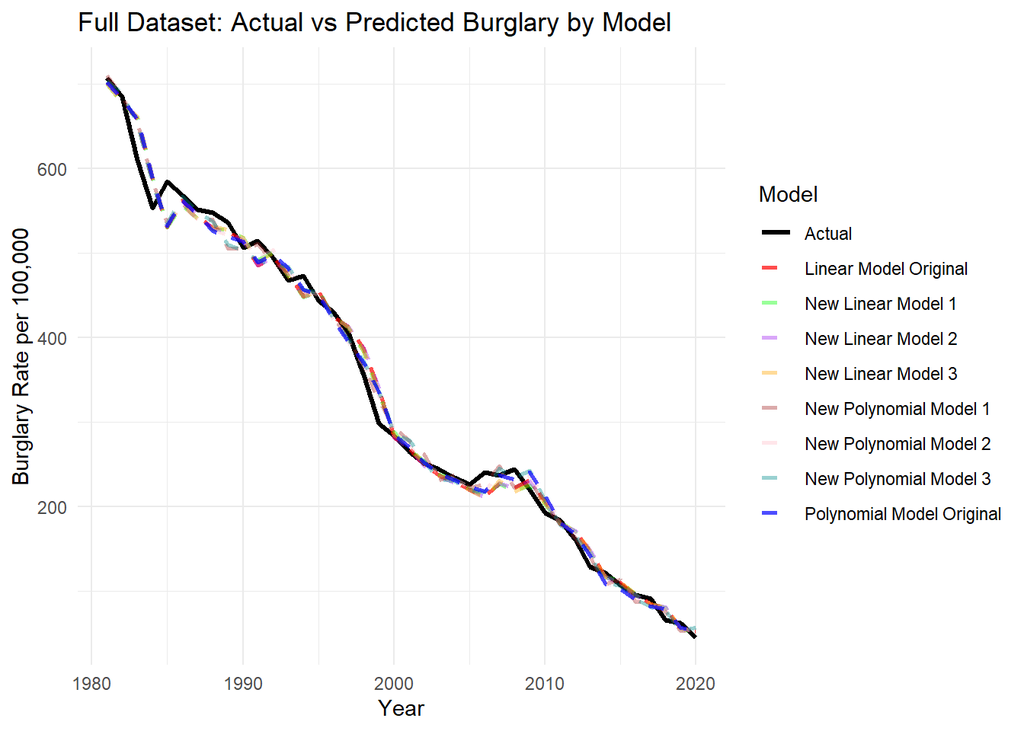

# CONCLUSION

In our analysis we attempted to answer two questions about our Scooby-Doo dataset. Question one focused on what factors about an episode can be used to predict the rating. We also looked at how the factors that are important to the ratings might change over time. While the factors that influenced ratings the most changed over time, we did see some patterns. We found that overall network, inclusion of special characters, whether the monster was real, and mystery gang member actions seemed to be the most important factors for predicting the rating of an episode. While a question relating to the ratings of a TV show might seem unimportant, our model could be of great use to the people who are working to create future media with these characters. Scooby-Doo producers could use our models to see what factors increased the ratings of the show as well as how those factors have changed over time. This might help them better decide what factors to include or not include in future episodes in order to make sure future episodes have high ratings. This would also create episodes that viewers will enjoy more, as typically higher-rated media tends to be overall more enjoyable for viewers. There were a few things for this question that could be investigated in the future. The first suggestion we have would be to look at the variables we struggled to include and figure out if there is a way to include them in our model. Some things that might make this possible would be to collect those variables in a different way or try to find a model type that is especially designed to work with difficult variables. The other suggestion we had for future analysis is to subdivide the data by series or network, like we subdivided by year, to see if subdividing by those variables would allow us to create models that are specialized for a specific series or network. This would allow producers of the show to only focus on the network their show will be airing on, or only focus on the series they are working on.

Our second question looked at juvenile crime data and whether there might be a connection between the crimes children are committing in real life and the ones they are watching on TV. For this question we created models to predict juvenile crime data and then added in Scooby-Doo factors to see if they improved our models. We did find that including Scooby-Doo factors did lead to the best model, but there wasn’t enough of a difference between the models that contained Scooby-Doo factors and those that did not to suggest that Scooby-Doo factors are influencing juvenile crime rates. This question holds real-world importance for both parents and law enforcement. If a strong relationship was found between juvenile crimes and Scooby-Doo, it could lead parents to decide not to show their children Scooby-Doo. Since we did not find a strong relationship, parents can safely assume that showing their children Scooby-Doo will not lead them to a life of crime. This question would also be relevant for law enforcement, as they could consider adding Scooby-Doo factors to their models predicting crime rates if they improved their models. Since we did not find a large improvement in the models when we added Scooby-Doo factors, law enforcement should probably continue using current models, but our analysis does allow them to know that Scooby-Doo factors are likely not worth the time to investigate if they wanted to improve their models in the future. Law enforcement could also choose to use one of our top initial models if they needed a good model for predicting juvenile crime rates based on last year’s data. One thing that could be investigated in the future is including gender in the model to see if that improves the model. Both datasets had a gender variable that could be included in the models to see if gender played a role in juvenile crime rates and if the gender of the villain in episodes of Scooby-Doo had any impact on the rate at which different genders are committing crimes in real life. We also thought it might be interesting to add data from other children’s shows that revolve around fighting crime or solving mysteries to see if those shows had any influence on children. Overall, our group was able to find some very interesting things about Scooby-Doo, what makes it so popular, and what impact it might be having on children.